# Brownlows Bets

Year 2020

# 1 Introduction

At the first day of class there are 35 students in Math Statistics class and professor Brownlow always proposes this bet to his students "I will wager $2 to your bet of $1 that at least two people in today’s class have the same birthday. He tells me he has made that bet 637 times so far. Where do you think his profits are? Discuss this in a markdown document

Report git commit structure: There are 3 questions and there should be at least 3 separate commits, at least one dealing with each of the 3 questions. 1. What are the fair odds for a bet on matching birthdays in a 35 person class. 2. For what size class is a 2:1 odds bet fair. 3. How much money would Brownlow be expected to end up with if the bets went as described.

```r
URN = 1:365
```

# 2 What are the fair odds

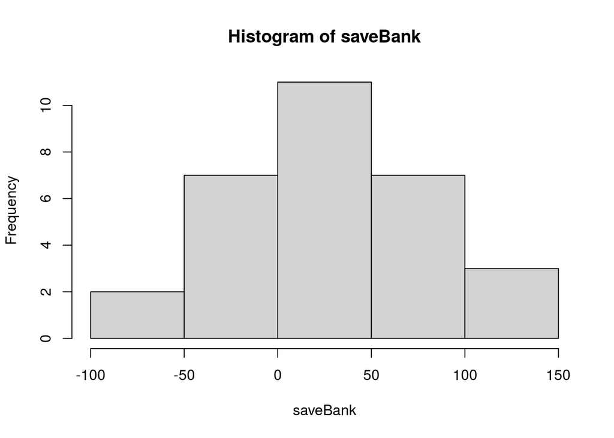

```r
classSize = 35
winAmount=1
loseAmount=4.25

test = vector('numeric')
saveBank=vector('numeric')
for (j in 1:30){
  bank=0
for(i in 1:637){
test = sample(URN, size=classSize, replace=TRUE)
ifelse(length(unique(test))==classSize, (bank=bank-loseAmount),(bank=bank+winAmount))
saveBank[j] = bank
}
}
hist(saveBank)
```

```r
favstats(saveBank)
```

```
##    min      Q1 median      Q3    max  mean       sd  n missing
##  -87.5 -7.4375  12.25 58.1875 138.25 22.75 54.36764 30       0
```

An odds ratio of 4.25:1 seems fair because it returns a low mean which means that it does not heavily favor one side or the other.

# 3 What size of class makes the 2:1 bet fair?

```r
URN = 1:365
```

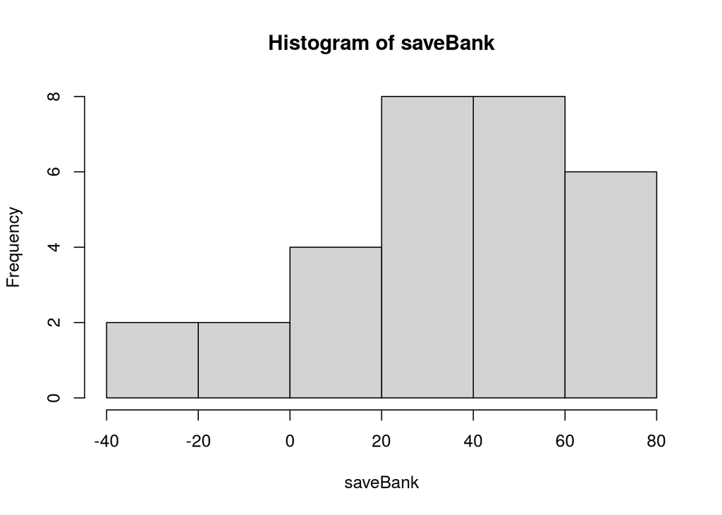

```r
classSize = 29
winAmount=1
loseAmount=2

test = vector('numeric')
saveBank=vector('numeric')
for (j in 1:30){
  bank=0
for(i in 1:637){
test = sample(URN, size=classSize, replace=TRUE)
ifelse(length(unique(test))==classSize, (bank=bank-loseAmount),(bank=bank+winAmount))
saveBank[j] = bank
}
}
hist(saveBank)
```

```r
favstats(saveBank)
```

```
##  min    Q1 median    Q3 max mean       sd  n missing
##  -26 15.25     37 51.25  79 33.5 28.57024 30       0
```

A class size between 28 and 29 people would make for a fair bet. At 28 people the odds are in favor of the class and at 29 they’re in favor of the professor.

# 4 In the class and payoff as described what is a 95% confidence interval for Brownlow’s earnings?

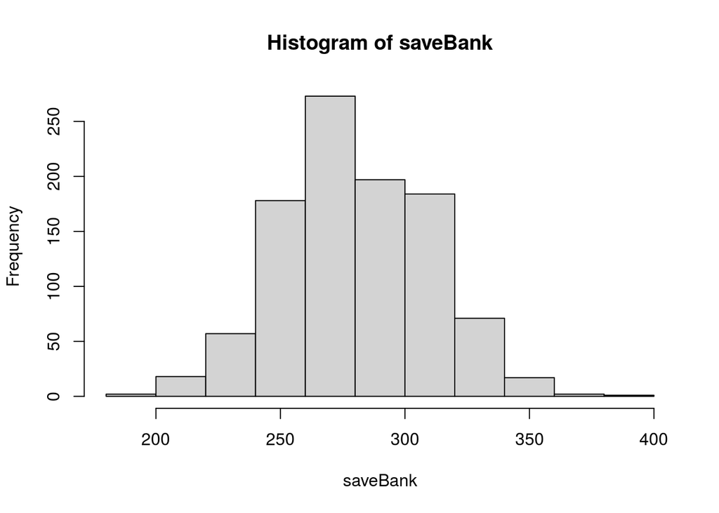

```r
classSize = 35
winAmount=1
loseAmount=2.00

test = vector('numeric')
saveBank=vector('numeric')
for (j in 1:1000){
  bank=0
for(i in 1:637){
test = sample(URN, size=classSize, replace=TRUE)
ifelse(length(unique(test))==classSize, (bank=bank-loseAmount),(bank=bank+winAmount))
saveBank[j] = bank
}
}
hist(saveBank)
```

```r
sortedBank <- sort(saveBank)
lcl<-sortedBank[25]
ucl<-sortedBank[975]
print(paste(lcl,ucl))
```

```
## [1] "226 337"
```

# 5 Discussion and Conclusion

He should increase his payout if his class size is around 35 students because once he goes over 28 students, the odds are in his favor. However, if his class size is 28 or less the odds are against him and he would want to decrease his payout in order to have his profits center on zero. The ideal class size for running this bet while issuing a 2:1 payout would be between 28 and 29 students if the goal was to have a profit centered on zero.